# PISA Data exploration

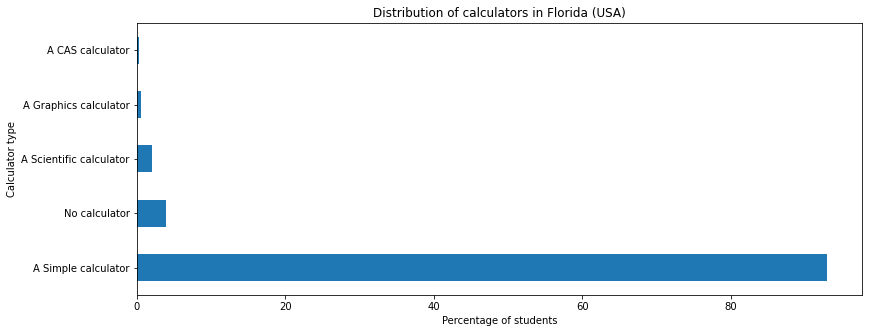

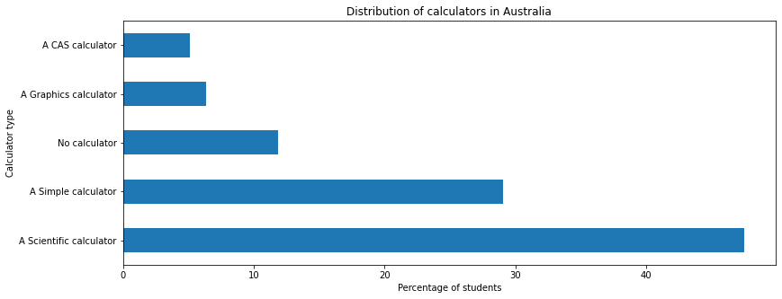

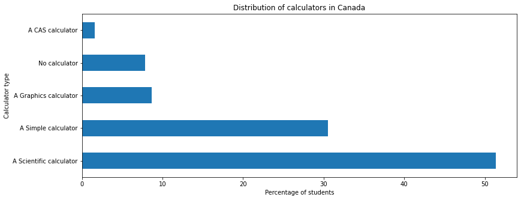

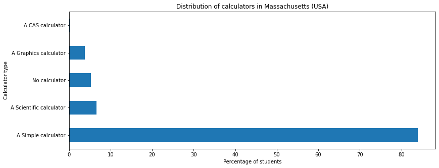

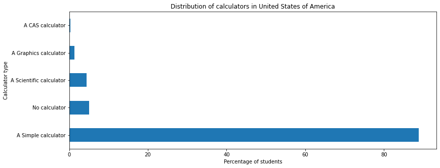

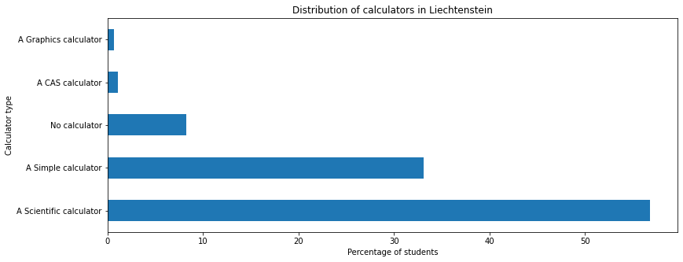

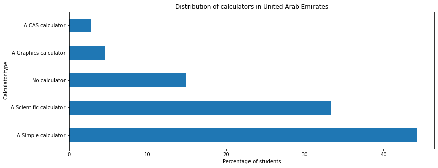

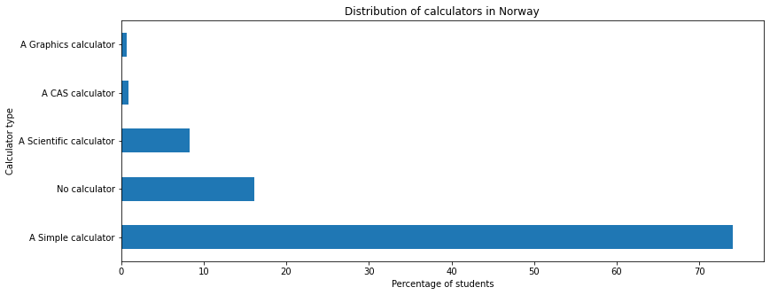

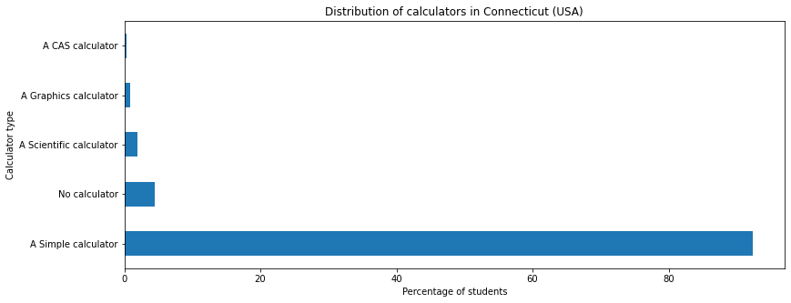

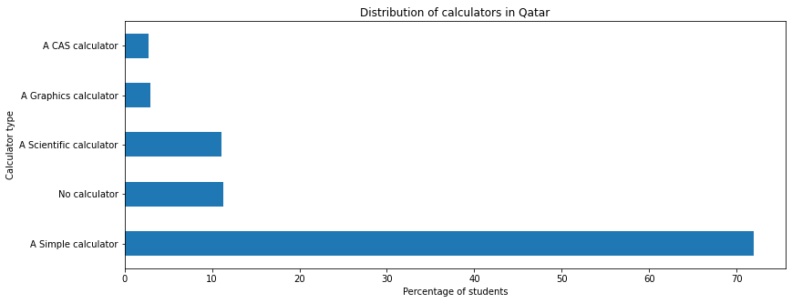

```python
for country in df.groupby('CNT')['WEALTH'].mean().sort_values(ascending = True).tail(10).index:
    country_calc(country)
```

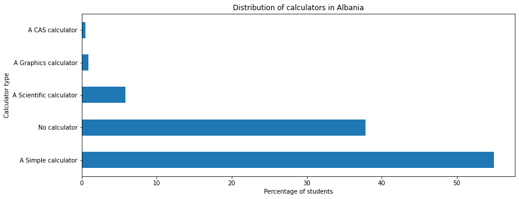

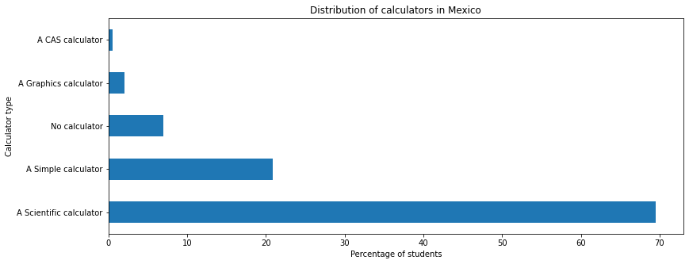

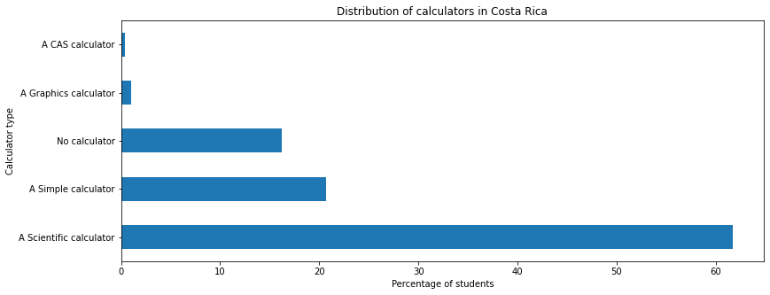

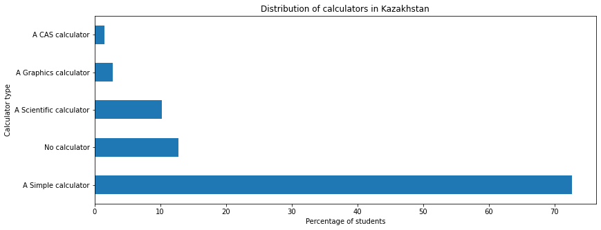

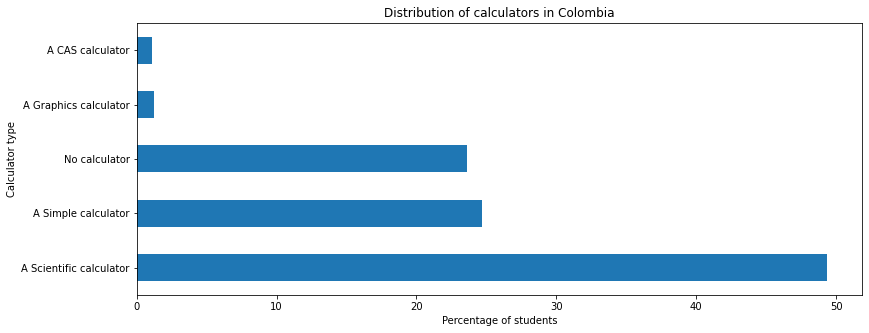

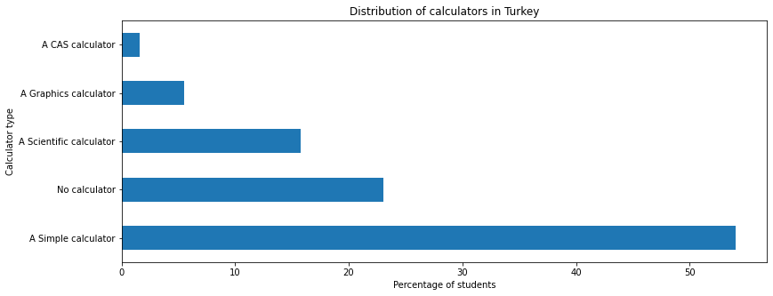

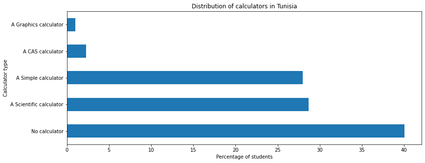

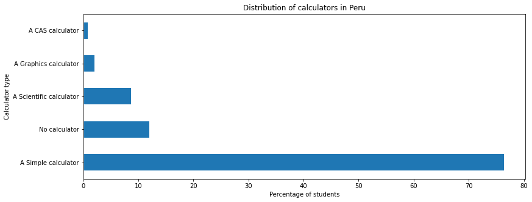

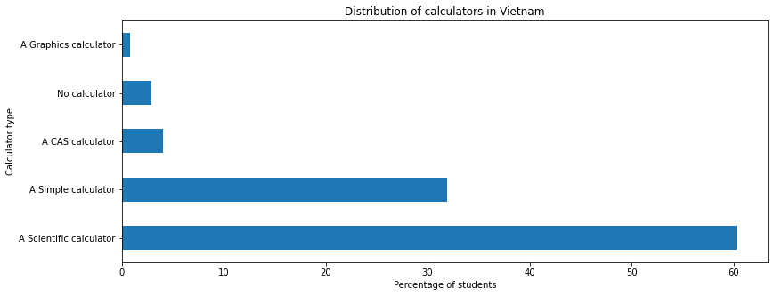

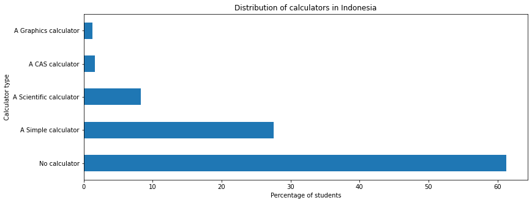

```python
for country in df.groupby('CNT')['WEALTH'].mean().sort_values(ascending = False).tail(10).index:
    country_calc(country)
```

Let's make a way to get the proportions easily

```python
group_by_clc = (df.groupby('CNT')['CLCUSE1'].value_counts(normalize=True)*100).rename('proportion').reset_index()
group_by_clc.head()
# Sort the dataframe by the desired calculator type
```

|  | CNT | CLCUSE1 | proportion |
| --- | --- | --- | --- |
| 0 | Albania | A Simple calculator | 54.966887 |
| 1 | Albania | No calculator | 37.821928 |
| 2 | Albania | A Scientific calculator | 5.813098 |
| 3 | Albania | A Graphics calculator | 0.883002 |
| 4 | Albania | A CAS calculator | 0.515085 |

Which country has the highest proportion of students using no calculators?

```python
(group_by_clc[group_by_clc.CLCUSE1 == 'No calculator'].
 sort_values(by = 'proportion', ascending = False)
 .head(20))
```

|  | CNT | CLCUSE1 | proportion |
| --- | --- | --- | --- |
| 130 | Indonesia | No calculator | 61.307235 |
| 210 | Montenegro | No calculator | 52.717115 |
| 155 | Jordan | No calculator | 47.222779 |
| 305 | Tunisia | No calculator | 40.062652 |
| 1 | Albania | No calculator | 37.821928 |
| 31 | Bulgaria | No calculator | 37.578999 |
| 266 | Serbia | No calculator | 34.748932 |
| 301 | Thailand | No calculator | 32.658170 |
| 256 | Romania | No calculator | 30.862208 |
| 151 | Japan | No calculator | 27.382528 |
| 111 | Greece | No calculator | 25.532387 |
| 51 | Chinese Taipei | No calculator | 23.944921 |
| 261 | Russian Federation | No calculator | 23.922176 |
| 57 | Colombia | No calculator | 23.622155 |
| 311 | Turkey | No calculator | 23.029655 |
| 181 | Lithuania | No calculator | 22.788712 |
| 166 | Korea | No calculator | 22.706372 |
| 192 | Macao-China | No calculator | 22.401656 |
| 231 | Perm(Russian Federation) | No calculator | 22.148099 |
| 332 | Uruguay | No calculator | 19.533142 |

```python
def age_compare_bar(series = None, figsize = (15,6),
                    figures = 2, add_annotate = '',
                    xlabel = None, ylabel = None, title = None):
    plt.subplots(figsize = figsize)
    y = list(range(len(series)))
    plt.barh(y = y, width = series, tick_label = series.index)
    for position in y:
        plt.annotate(str(round(series[position], figures))+ add_annotate, xy=(series[position]+ 1,y[position]))
    plt.xlabel(xlabel, fontsize = 16)
    plt.ylabel(ylabel, fontsize = 16)
    plt.title(title, fontsize = 20)
    plt.show()
```

```python
(group_by_clc[group_by_clc.CLCUSE1 == 'No calculator']
 [['CNT', 'proportion']].set_index('CNT')
 .squeeze().sort_values(ascending = False))
```

```
CNT
Indonesia                   61.307235
Montenegro                  52.717115
Jordan                      47.222779
Tunisia                     40.062652
Albania                     37.821928
                              ...
United States of America     5.081081
Singapore                    5.054509
Connecticut (USA)            4.468912
Florida (USA)                3.973139
Vietnam                      2.887606
Name: proportion, Length: 68, dtype: float64
```

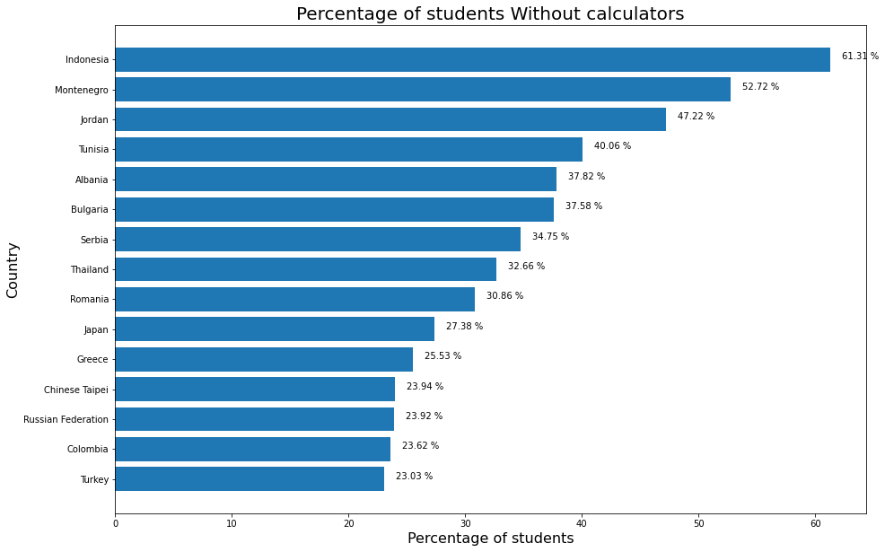

```python
age_compare_bar(series = (group_by_clc[group_by_clc.CLCUSE1 == 'No calculator'][['CNT', 'proportion']]
                 .set_index('CNT').squeeze().sort_values(ascending = True)).tail(15),
                xlabel = 'Percentage of students',
                ylabel = 'Country', figsize = (15,10),
                title = 'Percentage of students Without calculators', add_annotate = ' %')
```

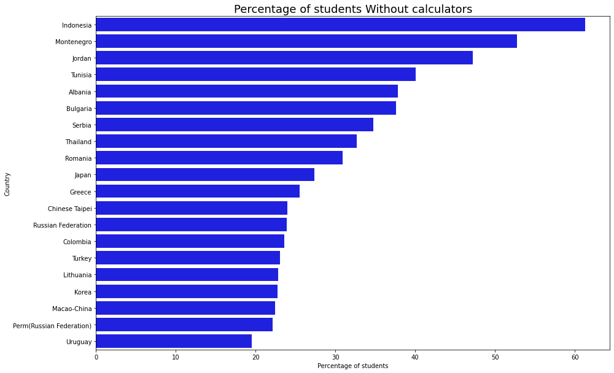

```python
plt.figure(figsize = (15,10))
color_map = sns.color_palette("Blues", as_cmap=True)
sns.barplot(data = group_by_clc[group_by_clc.CLCUSE1 == 'No calculator'].
            sort_values(by = 'proportion', ascending = False).head(20),
            y = 'CNT', x = 'proportion',
            orient = 'h', color = 'blue'
           );

plt.xlabel('Percentage of students')
plt.ylabel('Country')
plt.title('Percentage of students Without calculators', fontsize = 18);
```

Let's see which country is represented by the smartest people in this survey

```python
df['GRADE'] = df['GRADE'].astype(float)
```

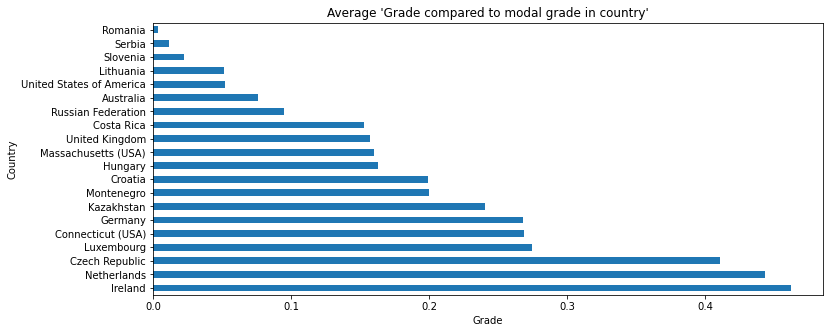

```python
df.groupby('CNT')['GRADE'].mean().sort_values(ascending = False).head(20).plot(kind = 'barh', figsize = (12, 5))
plt.title("Average 'Grade compared to modal grade in country'")
plt.xlabel("Grade")
plt.ylabel('Country');
```

```python
df.groupby('CNT')['GRADE'].mean().sort_values(ascending = False).tail(20)
```

```
CNT
Chile             -0.219224
France            -0.274442
Turkey            -0.279290
Mexico            -0.282465
Chinese Taipei    -0.330963
Colombia          -0.367464
Spain             -0.381899
Albania           -0.401223
Argentina         -0.406567
Hong Kong-China   -0.413704
Belgium           -0.418366
Slovak Republic   -0.464515
Austria           -0.507045
China-Shanghai    -0.519220
Tunisia           -0.531200
Portugal          -0.562296
Indonesia         -0.564746
Uruguay           -0.638946
Macao-China       -0.813683
Brazil            -0.855082
Name: GRADE, dtype: float64
```

This doesn't mean that the students from Ireland are the smartest on average. This simply means that the students chosen for this survey from Ireland were relatively smart compared to other students from their country

## Countries Wealth

Let's see the wealth distribution of students by country

```python
df.groupby('CNT')['WEALTH'].mean().sort_values(ascending = True).tail(10).to_frame()
```

| CNT | WEALTH |
| --- | --- |
| Florida (USA) | 0.480307 |
| Australia | 0.496489 |
| Canada | 0.508482 |
| Massachusetts (USA) | 0.513072 |
| United States of America | 0.536442 |
| Liechtenstein | 0.541394 |
| United Arab Emirates | 0.577770 |
| Norway | 0.693210 |
| Connecticut (USA) | 0.693351 |
| Qatar | 0.843554 |

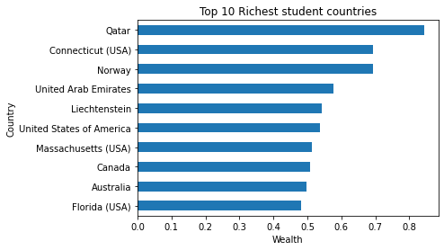

```python
df.groupby('CNT')['WEALTH'].mean().sort_values(ascending = True).tail(10).plot(kind = 'barh')
plt.title('Top 10 Richest student countries')
plt.xlabel('Wealth')
plt.ylabel('Country');
```

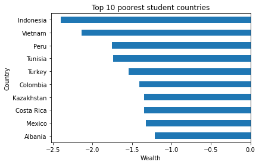

```python
df.groupby('CNT')['WEALTH'].mean().sort_values(ascending = False).tail(10).plot(kind = 'barh')
plt.title('Top 10 poorest student countries')
plt.xlabel('Wealth')
plt.ylabel('Country');
```

Let's see if wealth has any effect on grades

## Does wealth have an effect on grades?

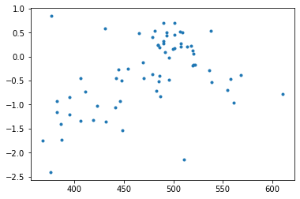

```python
plt.plot((df.groupby('CNT')[['PV1MATH', 'WEALTH']].mean())['PV1MATH'],
         (df.groupby('CNT')[['PV1MATH', 'WEALTH']].mean())['WEALTH'], marker = '.', linestyle = 'None')
```

```python
(df.groupby('CNT')[['PV1MATH', 'WEALTH']].mean())['PV1MATH'].corr((df.groupby('CNT')[['PV1MATH', 'WEALTH']].mean())['WEALTH'])
```

```
0.43476115920038105
```

There's a slight positive correlation

```python
df.groupby('GRADE')['WEALTH'].median()
```

```
GRADE
-3.0   -1.43
-2.0   -1.05
-1.0   -0.59
 0.0   -0.19
 1.0   -0.12
 2.0    0.03
 3.0   -1.65
Name: WEALTH, dtype: float64
```

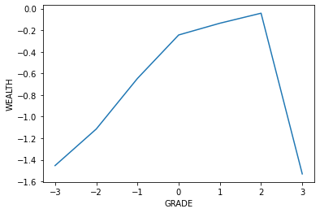

```python
df.groupby('GRADE')['WEALTH'].mean().plot()
plt.ylabel('WEALTH')
```

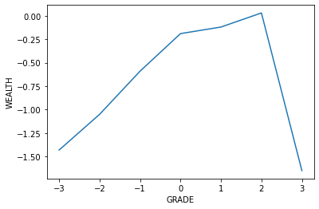

```python
df.groupby('GRADE')['WEALTH'].median().plot()
plt.ylabel('WEALTH')
```

Interesting dip at GRADE == 3. Let's investigate further

```python
df.query('GRADE == 3')['CNT'].value_counts()
```

```
Kazakhstan    5
Name: CNT, dtype: int64
```

Oh. So only Kazakhstan has students with GRADE 3 points above the modal country grade.

```python
df[df['CNT'] == 'Kazakhstan']['WEALTH'].mean()
```

```
-1.3489026701119522
```

```python
df.query('CNT=="Kazakhstan" & GRADE != 3')['WEALTH'].median()
```

```
-1.29
```

```python
df.groupby('GRADE')['PV1MATH'].mean()
```

```
GRADE
-3.0    322.751536
-2.0    361.468242
-1.0    428.509931
 0.0    482.692506
 1.0    493.464971
 2.0    507.052043
 3.0    447.180260
Name: PV1MATH, dtype: float64
```

```python
df_score_grade = df[['GRADE', 'PV1SCIE', 'PV1READ', 'PV1MATH']]
```

## Learning Assessment

Now let's look at these columns

1. OTL - Algebraic Word Problem in Math Lesson - 'ST73Q01'
2. OTL - Algebraic Word Problem in Tests - 'ST73Q02'

```python
df['ST73Q01'].unique()
```

```
array([nan, 'Frequently', 'Never ', 'Sometimes', 'Rarely '], dtype=object)
```

```python
df['ST73Q02'].unique()
```

```
array([nan, 'Sometimes', 'Frequently', 'Never ', 'Rarely '], dtype=object)
```

```python
df['ST73Q02'].notnull().sum()
```

```
308965
```

```python
df['ST73Q01'].notnull().sum()
```

```
309601
```

The amount of data in the two columns is almost equal so the count difference can be considered negligible

```python
df[['ST73Q01','ST73Q02']]
```

|  | ST73Q01 | ST73Q02 |
| --- | --- | --- |
| 0 | NaN | NaN |
| 1 | Frequently | Sometimes |
| 2 | Frequently | Frequently |
| 3 | Frequently | Sometimes |
| 4 | NaN | NaN |
| ... | ... | ... |
| 485485 | Rarely | Never |
| 485486 | NaN | NaN |
| 485487 | NaN | NaN |
| 485488 | Sometimes | Rarely |
| 485489 | Frequently | Rarely |

485490 rows × 2 columns

```python
pd.Series(np.zeros(len(df[['ST73Q02']])))
```

```
0         0.0
1         0.0
2         0.0
3         0.0
4         0.0
         ...
485485    0.0
485486    0.0
485487    0.0
485488    0.0
485489    0.0
Length: 485490, dtype: float64
```

```python
word_problem_intest = df[['ST73Q02']]
#.reset_index().drop(columns)
word_problem_intest['desc'] = pd.Series(np.zeros(len(df[['ST73Q02']])))
word_problem_intest['desc'] = word_problem_intest['desc'].replace(0.0, 'ST73Q02')
word_problem_intest = word_problem_intest.rename(columns = {'ST73Q02': 'Frequency'})
```

```python
word_problem_intest
```

|  | Frequency | desc |
| --- | --- | --- |
| 0 | NaN | ST73Q02 |
| 1 | Sometimes | ST73Q02 |
| 2 | Frequently | ST73Q02 |
| 3 | Sometimes | ST73Q02 |
| 4 | NaN | ST73Q02 |
| ... | ... | ... |
| 485485 | Never | ST73Q02 |
| 485486 | NaN | ST73Q02 |
| 485487 | NaN | ST73Q02 |
| 485488 | Rarely | ST73Q02 |
| 485489 | Rarely | ST73Q02 |

485490 rows × 2 columns

We'll do this often, so let's make a function

```python
def new_col(data, column_name):
    new_frame = df[[column_name]]
    new_frame['desc'] = pd.Series(np.zeros(len(new_frame)))
    new_frame['desc'] = new_frame['desc'].replace(0.0, column_name)
    new_frame.rename(columns = {column_name: 'Frequency'}, inplace = True)
    return new_frame
```

```python
word_problem_math_lesson = new_col(df, 'ST73Q01')
print("Shape: ", word_problem_math_lesson.shape)
word_problem_math_lesson.head()
```

```
Shape:  (485490, 2)
```

|  | Frequency | desc |
| --- | --- | --- |
| 0 | NaN | ST73Q01 |
| 1 | Frequently | ST73Q01 |
| 2 | Frequently | ST73Q01 |
| 3 | Frequently | ST73Q01 |
| 4 | NaN | ST73Q01 |

I'll now append the two DataFrames

```python
word_problem = pd.concat([word_problem_intest, word_problem_math_lesson])
print("Shape: ", word_problem.shape)
word_problem.head()
```

```
Shape:  (970980, 2)
```

|  | Frequency | desc |
| --- | --- | --- |
| 0 | NaN | ST73Q02 |
| 1 | Sometimes | ST73Q02 |
| 2 | Frequently | ST73Q02 |
| 3 | Sometimes | ST73Q02 |
| 4 | NaN | ST73Q02 |

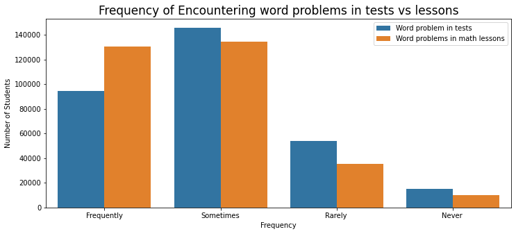

```python
plt.figure(figsize = (12, 5))
sns.countplot(data = word_problem, x = 'Frequency',
              hue = 'desc',
              order = ['Frequently','Sometimes', 'Rarely ', 'Never '])
plt.legend(loc = 'upper right', labels = ['Word problem in tests', 'Word problems in math lessons'])
plt.ylabel('Number of Students')
plt.xlabel('Frequency')
plt.title('Frequency of Encountering word problems in tests vs lessons', fontsize = 17);
```

Less students said that they encounter Word problems Frequently in tests than in math lessons. This plot seems to show that more word problems are encountered in maths lessons than in tests

We're going to do another similar analysis so let's make the function more robust

```python
def new_col(data, column_names):
    dataframes = []
    for column_name in column_names:
        new_frame = df[[column_name]]
        new_frame['desc'] = pd.Series(np.zeros(len(new_frame)))
        new_frame['desc'] = new_frame['desc'].replace(0.0, column_name)
        new_frame.rename(columns = {column_name: 'Frequency'}, inplace = True)
        dataframes.append(new_frame)

    full_frame = pd.concat(dataframes)
    return full_frame
```

Let's also make a function for plotting

```python
def side_by_side(data, order = None,
                label = None, loc = 'upper right'):

    plt.figure(figsize = (12, 5))
    sns.countplot(data = data, x = 'Frequency',
                  hue = 'desc', order = order)

    plt.legend(loc = loc, labels = label)
    plt.show()
```

## Let's Now look at two more related columns

'ST76Q01' which is the students response to how frequently they encountered Applied Math Reasoning in Math Lessons

and 'ST76Q02' which is how frequently they encountered Applied Math Reasoning in Tests.

We'll use our function to prepare the columns for side-by-side count plotting

```python
df['ST76Q02']
```

```
0               NaN
1         Sometimes
2           Rarely
3         Sometimes
4               NaN
            ...
485485       Never
485486          NaN
485487          NaN
485488      Rarely
485489      Rarely
Name: ST76Q02, Length: 485490, dtype: object
```

```python
df['ST76Q01']
```

```
0               NaN
1         Sometimes
2           Rarely
3         Sometimes
4               NaN
            ...
485485       Never
485486          NaN
485487          NaN
485488      Rarely
485489    Sometimes
Name: ST76Q01, Length: 485490, dtype: object
```

```python
applied_math_reasoning = new_col(df, [ 'ST76Q02','ST76Q01'])
applied_math_reasoning
```

|  | Frequency | desc |
| --- | --- | --- |
| 0 | NaN | ST76Q02 |
| 1 | Sometimes | ST76Q02 |
| 2 | Rarely | ST76Q02 |
| 3 | Sometimes | ST76Q02 |
| 4 | NaN | ST76Q02 |
| ... | ... | ... |
| 485485 | Never | ST76Q01 |
| 485486 | NaN | ST76Q01 |
| 485487 | NaN | ST76Q01 |
| 485488 | Rarely | ST76Q01 |
| 485489 | Sometimes | ST76Q01 |

970980 rows × 2 columns

Let's create a frequency order list since we will use this ordering a few times

```python
frequency_order = ['Frequently','Sometimes', 'Rarely ', 'Never ']
```

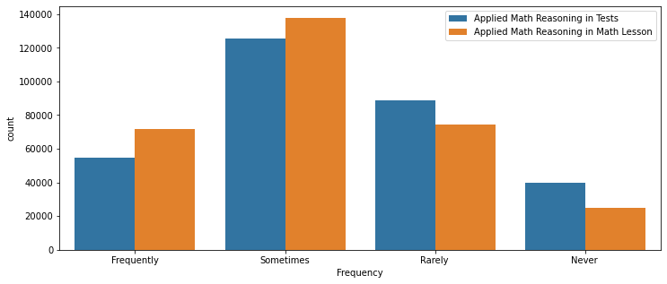

```python
side_by_side(data = applied_math_reasoning, order = frequency_order,
            label = ['Applied Math Reasoning in Tests', 'Applied Math Reasoning in Math Lesson'])
```

Less students also say that applied maths reasoning is encountered frequently in Tests than in lessons. This may be a signifier of lower quality test questions than lesson questions

Out of curiousity I just want to see if the people who say they Never get Applied math reasoning problems in tests, do better

```python
SADS_order = ['Strongly agree', 'Agree', 'Disagree', 'Strongly disagree']
```

```python
def compare_scores_dist(dictionary, scores, order = SADS_order,
                        xlabel = 'Average score (Plausible Value)',
                        title = None):
    """
    dictionary: A dictionary with keys being a column's code names and values being the column's describtion
    scores: The column of scores who's distribution you want to look at
    order: The order in which to display the boxplots.
           Usually an ordinal arrangement of the unique values of the column reffered to in the dictionary

    """
    for column in dictionary:
        plt.figure(figsize = (15,6))
        sns.boxplot(data = df, x = scores,
                    y= column , order = order)

        plt.ylabel(f"")
        plt.xlabel(xlabel);
        if title:
            plt.title(title, fontsize = 18)
        else:
            plt.title(f"Distribution of Math scores by '{dictionary[column]}'", fontsize = 18)
```

```python
applied_math_dict = {
    'ST76Q02' : 'Applied Math Reasoning in Tests',
    'ST76Q01' : 'Applied Math Reasoning in Math Lesson'
}
```

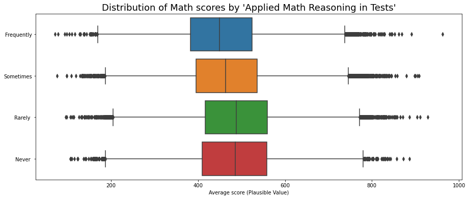

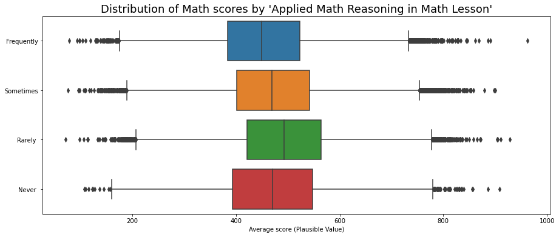

```python
compare_scores_dist(dictionary=applied_math_dict,
                   scores='PV1MATH', order = frequency_order)
```

So the people who think that applied reasoning is required less frequently in math tests than in lessons, have a slightly better math grade than those who think it comes up more frequently

```python
applied_reasoning_in_test = (df
.groupby('ST76Q02')['PV1MATH'].mean()
.sort_values().reindex(frequency_order)).rename('Average math score')
applied_reasoning_in_test.index.name = 'Applied Math Reasoning in Tests'
applied_reasoning_in_test
```

```
Applied Math Reasoning in Tests
Frequently    456.194677
Sometimes     467.764135
Rarely        488.730861
Never         483.989712
Name: Average math score, dtype: float64
```

## Calculator Type

Let's first see what effect type of calculator being used can have on math score

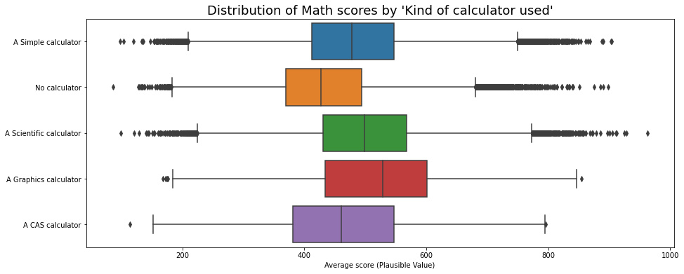

```python
calc_use_dict = {'CLCUSE1': 'Kind of calculator used'}
compare_scores_dist(dictionary=calc_use_dict,
                   scores='PV1MATH', order = None)
```

This indicates that graphing calculators may give students a chance at better math performance. This is also reflected in the average modal grades.

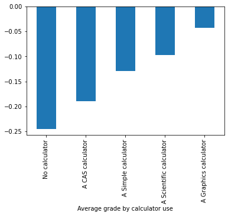

```python
df.groupby('CLCUSE1')['GRADE'].mean().sort_values().plot(kind = "bar")
plt.xlabel('Average grade by calculator use')
```

The below plot shows that students with the graphics calculator even spend less hours outside school, studying. Life seems to be smooth for these guys.

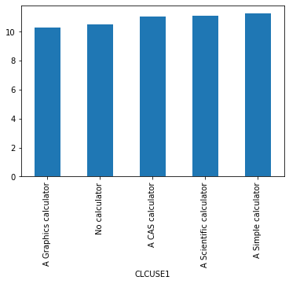

```python
df.groupby('CLCUSE1')['OUTHOURS'].mean().sort_values().plot(kind = "bar")
```

Why don't more people have the graphing calculator? Could it be very expensive? Let's look at the wealth distribution of the students who use the various kinds of calculators

```python
def compare_scores_dist(dictionary, scores, order = SADS_order, scores_to_measure = 'Math scores',
                        xlabel = 'Average score (Plausible Value)',
                        title = None):
    """
    dictionary: A dictionary with keys being a column's code names and values being the column's describtion
    scores: The column of scores who's distribution you want to look at
    order: The order in which to display the boxplots.
           Usually an ordinal arrangement of the unique values of the column reffered to in the dictionary

    """
    for column in dictionary:
        plt.figure(figsize = (15,6))
        sns.boxplot(data = df, x = scores,
                    y= column , order = order)

        plt.ylabel(f"")
        plt.xlabel(xlabel)
        if title:
            plt.title(title, fontsize = 18)
        else:
            plt.title(f"Distribution of {scores_to_measure} by '{dictionary[column]}'", fontsize = 18)
```

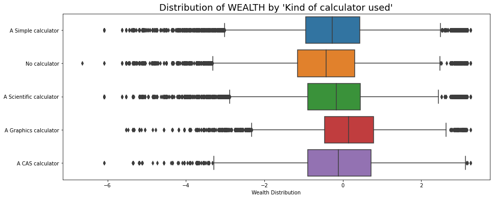

```python
compare_scores_dist(dictionary=calc_use_dict, scores='WEALTH',
                    xlabel = 'Wealth Distribution', order = None,
                   title = f"Distribution of WEALTH by 'Kind of calculator used'")
```

So yeah, the students with graphics calculators have a little more wealth at their disposal, but the little difference in wealth doesn't look like a convincing reason why a lot more people don't use graphing calculators. I think some attention should be brought to this situation

## Assessment of Attitude to Success

We shall now look at these columns:

> Can Succeed with Enough Effort - 'ST43Q01'

> Doing well is completely up to me - 'ST43Q02'

Can suceed with enough effort:

```python
df['ST43Q01'].unique()
```

```
array(['Agree', 'Strongly agree', nan, 'Disagree', 'Strongly disagree'],
      dtype=object)
```

Let's make a list that will represent the order of order = ['Strongly agree', 'Agree', 'Disagree', 'Strongly disagree']

Doing well is completely up to me:

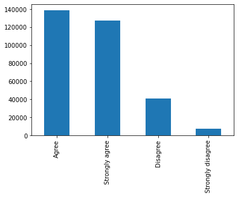

```python
df['ST43Q02'].value_counts().plot(kind = 'bar')
```

So we'll put these together so that we can plot them side_to_side

```python
success_effort = new_col(df, [ 'ST43Q01','ST43Q02'])

success_effort.reset_index()
```

|  | index | Frequency | desc |
| --- | --- | --- | --- |
| 0 | 0 | Agree | ST43Q01 |
| 1 | 1 | Strongly agree | ST43Q01 |
| 2 | 2 | Strongly agree | ST43Q01 |
| 3 | 3 | NaN | ST43Q01 |
| 4 | 4 | Strongly agree | ST43Q01 |
| ... | ... | ... | ... |
| 970975 | 485485 | Agree | ST43Q02 |
| 970976 | 485486 | Agree | ST43Q02 |
| 970977 | 485487 | Agree | ST43Q02 |
| 970978 | 485488 | NaN | ST43Q02 |
| 970979 | 485489 | Strongly agree | ST43Q02 |

970980 rows × 3 columns

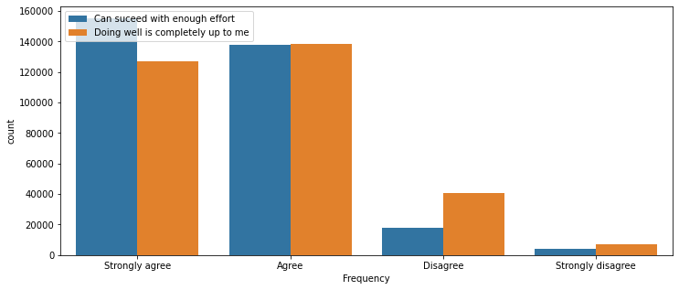

```python
side_by_side(data = success_effort, loc = 'upper left',
             order = SADS_order,
             label=['Can suceed with enough effort', 'Doing well is completely up to me'])
```

Less people believe that doing well is completely up to them than believe that they can succeed with enough effort. The students believe more that succeding is up to them, than that doing well is up to completely up to them

Let's see how the students' country influences their belief that doing well is completely up to them

```python
group_by_DWCUTM = (df.groupby('CNT')['ST43Q02'].value_counts(normalize=True)*100).rename('proportion (%)').reset_index()
group_by_DWCUTM.head()
```

|  | CNT | ST43Q02 | proportion (%) |
| --- | --- | --- | --- |
| 0 | Albania | Strongly agree | 50.419207 |
| 1 | Albania | Agree | 42.149390 |
| 2 | Albania | Disagree | 6.250000 |
| 3 | Albania | Strongly disagree | 1.181402 |
| 4 | Argentina | Strongly agree | 50.744652 |

```python
group_by_DWCUTM[group_by_DWCUTM['ST43Q02'] == 'Strongly disagree'].sort_values(by = 'proportion (%)', ascending = False).head(20)
```

|  | CNT | ST43Q02 | proportion (%) |
| --- | --- | --- | --- |
| 247 | Tunisia | Strongly disagree | 11.669659 |
| 203 | Qatar | Strongly disagree | 5.648878 |
| 127 | Jordan | Strongly disagree | 5.286738 |
| 151 | Luxembourg | Strongly disagree | 4.273504 |
| 91 | Greece | Strongly disagree | 3.838143 |
| 83 | France | Strongly disagree | 3.803433 |
| 115 | Israel | Strongly disagree | 3.702542 |
| 159 | Malaysia | Strongly disagree | 3.454384 |
| 231 | Spain | Strongly disagree | 3.393502 |
| 87 | Germany | Strongly disagree | 3.340517 |
| 207 | Romania | Strongly disagree | 3.290458 |
| 195 | Poland | Strongly disagree | 3.144448 |
| 255 | United Arab Emirates | Strongly disagree | 3.112369 |
| 143 | Liechtenstein | Strongly disagree | 3.108808 |
| 119 | Italy | Strongly disagree | 3.099224 |
| 171 | Montenegro | Strongly disagree | 3.037231 |
| 175 | Netherlands | Strongly disagree | 3.024911 |
| 155 | Macao-China | Strongly disagree | 3.018336 |
| 99 | Hungary | Strongly disagree | 2.871568 |
| 239 | Switzerland | Strongly disagree | 2.802600 |

```python
group_by_DWCUTM[group_by_DWCUTM['ST43Q02'] == 'Disagree'].sort_values(by = 'proportion (%)', ascending = False).head(20)
```

|  | CNT | ST43Q02 | proportion (%) |
| --- | --- | --- | --- |
| 61 | Czech Republic | Disagree | 23.915558 |
| 246 | Tunisia | Disagree | 23.231598 |
| 154 | Macao-China | Disagree | 22.172073 |
| 193 | Poland | Disagree | 21.749099 |
| 98 | Hungary | Disagree | 20.732092 |
| 110 | Ireland | Disagree | 19.393939 |
| 174 | Netherlands | Disagree | 19.323843 |
| 114 | Israel | Disagree | 18.198933 |
| 82 | France | Disagree | 18.074722 |
| 158 | Malaysia | Disagree | 18.039563 |
| 94 | Hong Kong-China | Disagree | 17.858309 |
| 230 | Spain | Disagree | 17.677497 |
| 74 | Finland | Disagree | 17.612045 |
| 18 | Belgium | Disagree | 17.546441 |
| 142 | Liechtenstein | Disagree | 17.098446 |
| 90 | Greece | Disagree | 17.078251 |
| 214 | Serbia | Disagree | 16.933333 |
| 222 | Slovak Republic | Disagree | 16.672202 |
| 238 | Switzerland | Disagree | 16.490658 |
| 242 | Thailand | Disagree | 16.446770 |

Let's see the attitude of the students to problem solving based on their belief concerning success

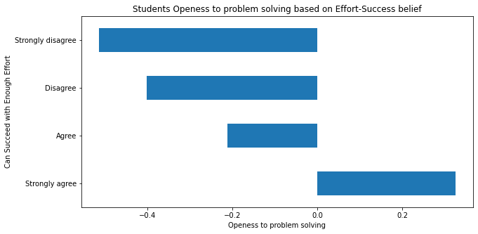

```python
df.groupby('ST43Q01')['OPENPS'].mean().sort_values().reindex(SADS_order).plot(kind = 'barh', figsize = (10,5))
plt.xlabel('Openess to problem solving')
plt.ylabel('Can Succeed with Enough Effort')
plt.title('Students Openess to problem solving based on Effort-Success belief');
```

```python
success_dict ={
    'ST43Q01' : 'Can suceed with enough effort',
    'ST43Q02' : 'Doing well is completely up to me'
}
```

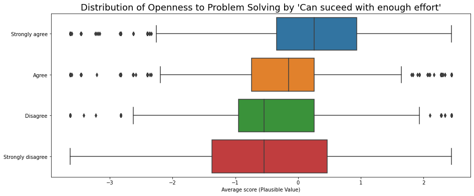

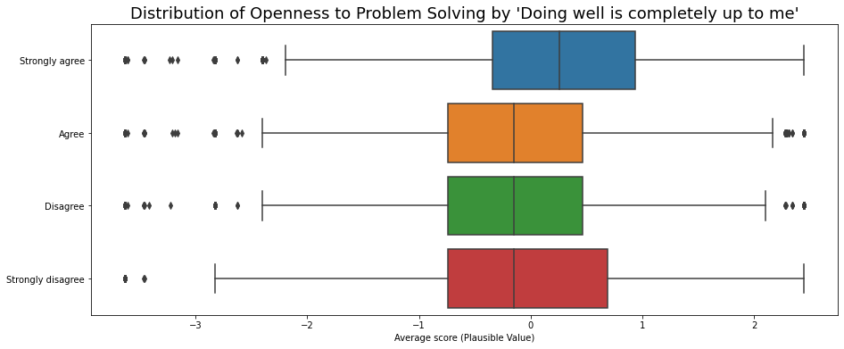

```python
compare_scores_dist(dictionary=success_dict, scores_to_measure = 'Openness to Problem Solving',
                    scores='OPENPS',)
```

If the team/group work came to mind immediately a student heard the question, they would more readily pick disagree/strongly disagree. But generally, the students who relate their success with their personal effort seem to be more open to problem solving

## Let's now look a little into parental influence

> Parents Believe Mathematics Is Important for Career - 'ST35Q05'

> Parents Like Maths - 'ST35Q06'

```python
parent_influence = new_col(df, [ 'ST35Q05','ST35Q06'])

parent_influence.reset_index()
```

|  | index | Frequency | desc |
| --- | --- | --- | --- |
| 0 | 0 | Agree | ST35Q05 |
| 1 | 1 | Disagree | ST35Q05 |
| 2 | 2 | Strongly agree | ST35Q05 |
| 3 | 3 | NaN | ST35Q05 |
| 4 | 4 | Strongly agree | ST35Q05 |
| ... | ... | ... | ... |
| 970975 | 485485 | Agree | ST35Q06 |
| 970976 | 485486 | Agree | ST35Q06 |
| 970977 | 485487 | Disagree | ST35Q06 |
| 970978 | 485488 | NaN | ST35Q06 |
| 970979 | 485489 | Strongly agree | ST35Q06 |

970980 rows × 3 columns

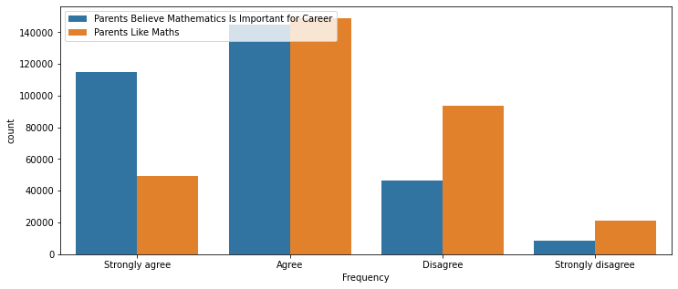

```python
side_by_side(data = parent_influence, loc = 'upper left',
             order = SADS_order,
             label=['Parents Believe Mathematics Is Important for Career', 'Parents Like Maths '])
```

Many of the parents who don't like maths still agree that it's important for their childrens' careers. Let's see how this changes when spit into genders

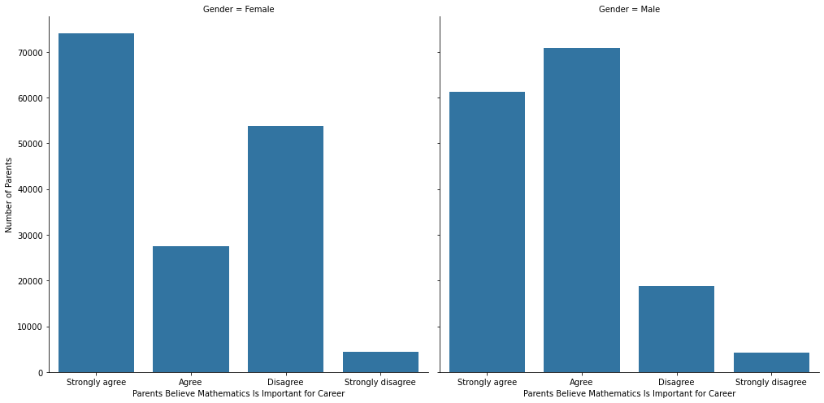

```python
g = sns.FacetGrid(data = df.rename(columns = {"ST04Q01": 'Gender',
                                             'ST35Q05':'Parents Believe Mathematics Is Important for Career'}),
                  col = 'Gender', height = 7)
g.map(sns.countplot, 'Parents Believe Mathematics Is Important for Career')
g.set_ylabels('Number of Parents')
```

For males, the distribution is the same but a lot more parents disagree that maths is important for their daughters' careers. Gender equality seems to still have a long way to go among the older generation (lol)

Let's see if these affects students mathematics score

```python
parents_math_view = {
    'ST35Q05' : 'Parents Believe Mathematics Is Important for Career',
    'ST35Q06' : 'Parents Like Maths'
}
```

```python
SADS_order
```

```
['Strongly agree', 'Agree', 'Disagree', 'Strongly disagree']
```

Let's make a boxplot function that will be used to compare scores distribution grouped by a variety of factors

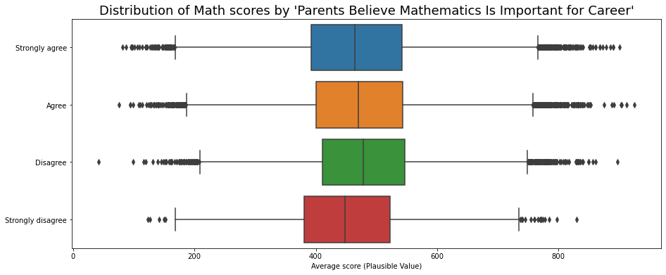

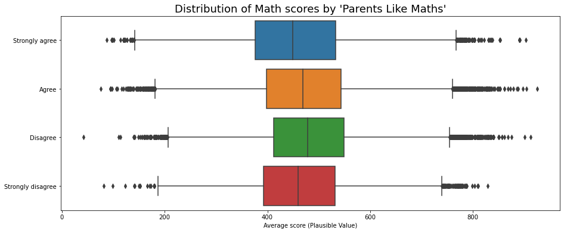

```python
compare_scores_dist(dictionary=parents_math_view,
                    scores='PV1MATH' )
```

```python
df_gendered = df.rename(columns = {"ST04Q01": 'Gender',
                                             'ST35Q05':'Parents Believe Mathematics Is Important for Career'})
```

### Did you observe any interesting relationships between the other features (not the main feature(s) of interest)?

> Yeah Kazakhstan is only represented by students who performed greatly in their countries. Survey sample should probably be more encompassing. The average wealth seemed to increase with each grade level except Kazakhztan. What could this mean?

## Multivariate Exploration

> Create plots of three or more variables to investigate your data even further. Make sure that your investigations are justified, and follow from your work in the previous sections.

Let's now explore how Gender and number of books owned affects reading score

```python
df1 = df[["ST28Q01", "ST04Q01",'PV1SCIE', 'PV1READ', 'PV1MATH']]
```

```python
course_dict.keys()
```

```
dict_keys(['PV1SCIE', 'PV1READ', 'PV1MATH'])
```

```python
df1 = df1.rename(columns = {"ST28Q01": 'Number of books owned',
                                             "ST04Q01": 'Gender'})
```

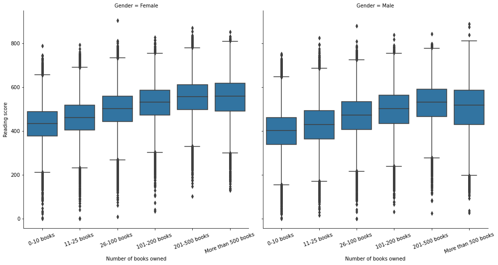

```python
g = sns.FacetGrid(data = df1 ,
                  col = 'Gender', height = 7)
g.map(sns.boxplot, 'Number of books owned', 'PV1READ', order = num_books)
g.set_xticklabels(rotation = 20)
g.set_ylabels('Reading score');
```

```python
course_dict
```

```
{'PV1SCIE': 'Science', 'PV1READ': 'Reading', 'PV1MATH': 'Math'}
```

```python
df1
```

|  | Number of books owned | Gender | PV1SCIE | PV1READ | PV1MATH |
| --- | --- | --- | --- | --- | --- |
| 0 | 0-10 books | Female | 341.7009 | 249.5762 | 406.8469 |
| 1 | 201-500 books | Female | 548.9929 | 406.2936 | 486.1427 |
| 2 | More than 500 books | Female | 499.6643 | 401.2100 | 533.2684 |
| 3 | 11-25 books | Female | 438.6796 | 547.3630 | 412.2215 |
| 4 | 101-200 books | Female | 361.5628 | 311.7707 | 381.9209 |
| ... | ... | ... | ... | ... | ... |
| 485485 | 26-100 books | Female | 559.8098 | 460.2272 | 477.1849 |
| 485486 | 26-100 books | Male | 538.7355 | 490.9325 | 518.9360 |
| 485487 | 0-10 books | Male | 536.8706 | 462.6239 | 475.2376 |
| 485488 | 26-100 books | Male | 511.0407 | 505.2873 | 550.9503 |
| 485489 | 0-10 books | Female | 530.6229 | 532.3506 | 470.0187 |

485490 rows × 5 columns

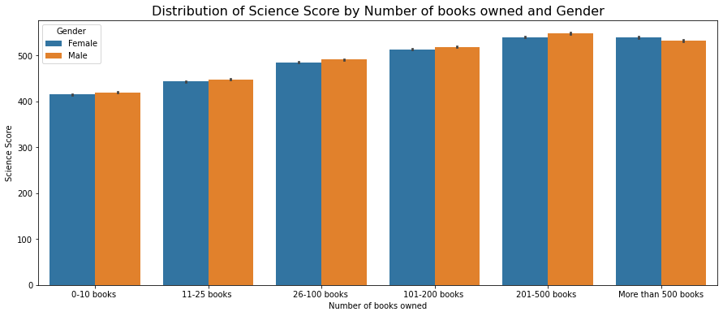

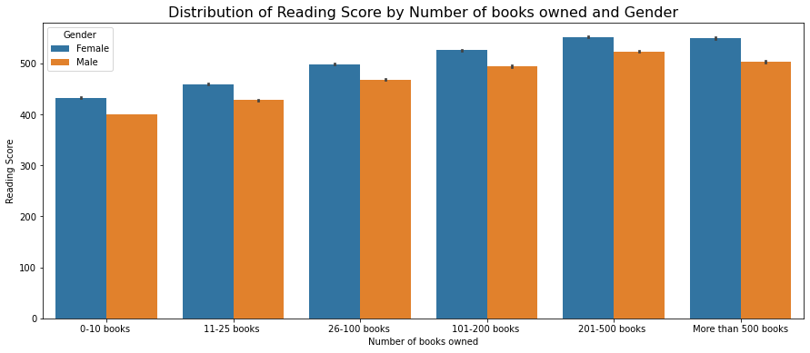

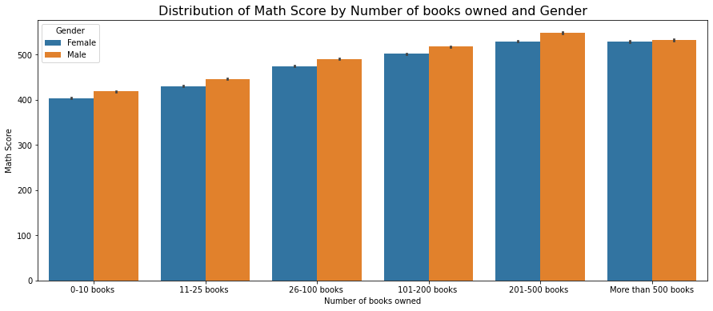

```python
for column in course_dict:
    plt.figure(figsize = (15,6))
    sns.barplot(data=df1, x="Number of books owned", y=column, hue="Gender", order = num_books)
    plt.title(f'Distribution of {course_dict[column]} Score by Number of books owned and Gender', fontsize = 16)
    plt.ylabel(f'{course_dict[column]} Score')
```

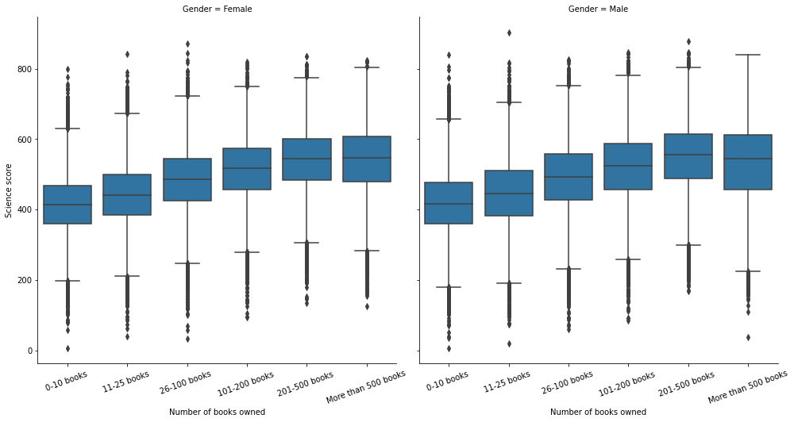

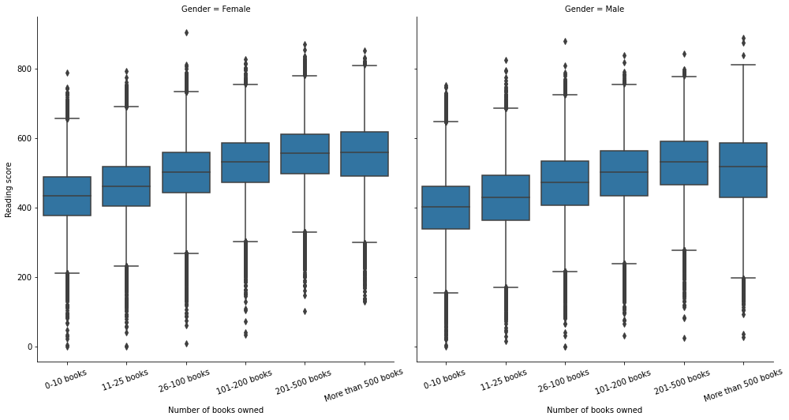

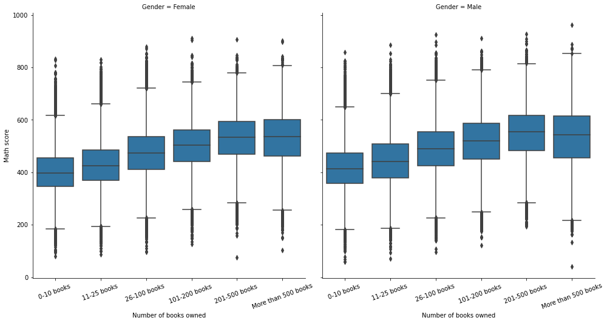

```python
for column in course_dict:
    g = sns.FacetGrid(data = df1,
                  col = 'Gender', height = 7)
    g.map(sns.boxplot, 'Number of books owned', column, order = num_books)
    g.set_xticklabels(rotation = 20)
    g.set_ylabels(f'{course_dict[column]} score')
    plt.show()
```

This plot shows that the students with more books had higher reading scores for females. However, for males, the ones with more than 500 books score somewhat less than the ones with 201-500 books. Also, females generally have higher reading scores than males

I also want to see if the the importance their parants place on mathematics for their careers affects their math scores

```python
df2 = df[["ST04Q01", 'ST35Q05', 'PV1MATH']]
df2.rename(columns = {"ST04Q01": 'Gender',
                     'ST35Q05':'Parents Believe Mathematics Is Important for Career'}, inplace = True)
```

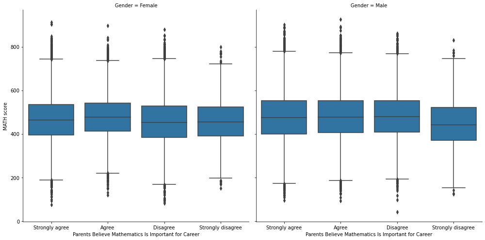

```python
g = sns.FacetGrid(data = df2,
                  col = 'Gender', height = 7)
g.map(sns.boxplot, 'Parents Believe Mathematics Is Important for Career', 'PV1MATH')
g.set_ylabels('MATH score')
```

```python
color = sns.color_palette()[0]
```

## Conclusions

Students in Peru have the lowest scores in all categories. Students in Shanghai China have the highest scores in all categories. Why?

Indonesia has the poorest average WEALTH. It also has the highest proportion of students who use no calculators, with 61%. It has the 2nd least average maths score. Children in indonesia need to be provided calculators. Peru has the 3rd least wealth average. Quatar is the richest bu it seems like their money is invested in places other than their children's education😅😅